# Supervisor meeting 4

Anna Hutchinson

26/10/2018

### Aim: Explore relationships between variables for ordered and non-ordered sets.

#### Method: Pairs plots, heatmap, correlation networks, logistic regression.

##### Authors claim that coverage ~ size in non-ordered sets. We hope that by incorporating information on both the size and the entropy of the system in ordered sets, we can better predict coverage. I.E. we hope that entropy describes the way set size changes for ordered sets, such that information on the OR (not known to experimentors) is not needed to predict coverage.

A new dataset has been created using reference haplotypes with $MAF=0.5$, $LD1=0.2$ and $LD2=0.08$.

$OR=1.3$ has been dropped from the dataset as this represents systems with very high entropy, with the CV holding a large proportion of the posterior probability. Moreover, these CVs are likely to have been identified by previous GWAS.

OR = 1, 1.05, 1.08, 1.1, 1.15, 1.2.

N = 1000, 2000, 3000, 4000, 5000.

thr = 0.5, 0.6, 0.7, 0.8, 0.9.

nsnps = 100, 200, 300, 500, 1000.

## Pairs plot

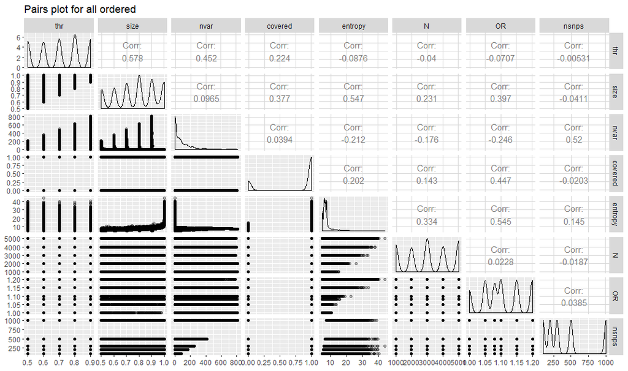

Pairs plot for ordered

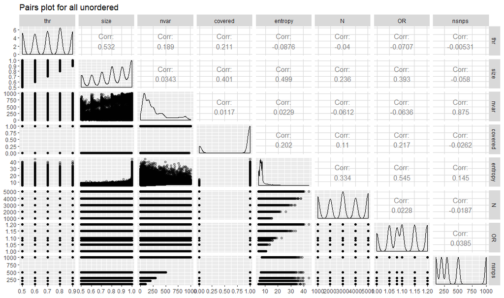